# GLMs in R

Sasha Ajay Malkani

2025-11-19

## 1. Installing Bioconductor package

```r
# if (!require("BiocManager", quietly = TRUE))
#   install.packages("BiocManager")
# BiocManager::install()
```

## 2. Installing “MASS”, “DESeq2”

```r
# BiocManager::install(c("MASS", "DESeq2"), type = "source", force = TRUE)
```

## 3. Troubleshooting installing packages

```r
BiocManager::valid()
```

## 4. Load Libraries

```r
library(devtools)
library(Biobase)
library(snpStats)
library(broom)
library(MASS)
library(DESeq2)
```

## 5. Making the plots prettier

```r
tropical = c("darkorange", "dodgerblue", "hotpink", "limegreen", "yellow")
```

## 6. Use the palette command to direct R to use those colors outlined above

```r
palette(tropical)
```

## 7. Making the circles on the plots filled solid

```r
par(pch=19)
```

## 8. Load Data from snpStats package

```r
data(for.exercise)
ls()
```

```
## [1] "snp.support"     "snps.10"         "subject.support" "tropical"
```

## 9. Subset data so the data is computationally easier to handle

```r
use <- seq(1, ncol(snps.10), 10)
head(use)
```

```
## [1]  1 11 21 31 41 51
```

## 10. Take the created subset to reduce the size of the data set

```r
sub.10 <- snps.10[,use]
sub.10
```

```
## A SnpMatrix with  1000 rows and  2851 columns
## Row names:  jpt.869 ... ceu.464
## Col names:  rs7909677 ... rs12218790
```

## 11. Calculate the Principal Components (PC’s)

### 11. A. Right transformation of the data to get the xx transpose

```r
xxmat <- xxt(sub.10, correct.for.missing=FALSE)
```

### 11. B. Calculate the Eigen vectors

```r
evv <- eigen(xxmat, symmetric=TRUE)
```

### 11. C. Calculate the PC’s

```r
pcs <- evv$vectors[,1:5]
head(pcs)
```

```
##             [,1]        [,2]         [,3]          [,4]         [,5]
## [1,] -0.03035563  0.01348902  0.007227560  0.0318879144  0.013097028
## [2,] -0.03321536 -0.03125111  0.005161250  0.0008124219 -0.011261681
## [3,] -0.02966065  0.01797856 -0.029403593  0.0031548111 -0.033863614
## [4,]  0.03027630 -0.01660208  0.004257012 -0.0145410857 -0.004785682
## [5,]  0.03014032 -0.02097615  0.036774119 -0.0196440818 -0.016567135
## [6,]  0.03084429  0.01175893 -0.019886428 -0.0269382792 -0.034101200
```

### 11. D.Dimensions of PC’s matrix

```r
dim(pcs)
```

```
## [1] 1000    5
```

## 12. Subset out data into R format so it’s easy to process

```r
snpdata = sub.10@.Data
dim(snpdata)
```

```
## [1] 1000 2851
```

## 13. Case Control status

```r
status = subject.support$cc
status
```

```
##    [1] 0 0 0 0 0 0 0 0 0 0 0 0 0 0 0 0 0 0 0 0 0 0 0 0 0 0 0 0 0 0 0 0 0 0 0 0 0
##   [38] 0 0 0 0 0 0 0 0 0 0 0 0 0 0 0 0 0 0 0 0 0 0 0 0 0 0 0 0 0 0 0 0 0 0 0 0 0
##   [75] 0 0 0 0 0 0 0 0 0 0 0 0 0 0 0 0 0 0 0 0 0 0 0 0 0 0 0 0 0 0 0 0 0 0 0 0 0
##  [112] 0 0 0 0 0 0 0 0 0 0 0 0 0 0 0 0 0 0 0 0 0 0 0 0 0 0 0 0 0 0 0 0 0 0 0 0 0
##  [149] 0 0 0 0 0 0 0 0 0 0 0 0 0 0 0 0 0 0 0 0 0 0 0 0 0 0 0 0 0 0 0 0 0 0 0 0 0
##  [186] 0 0 0 0 0 0 0 0 0 0 0 0 0 0 0 0 0 0 0 0 0 0 0 0 0 0 0 0 0 0 0 0 0 0 0 0 0
##  [223] 0 0 0 0 0 0 0 0 0 0 0 0 0 0 0 0 0 0 0 0 0 0 0 0 0 0 0 0 0 0 0 0 0 0 0 0 0
##  [260] 0 0 0 0 0 0 0 0 0 0 0 0 0 0 0 0 0 0 0 0 0 0 0 0 0 0 0 0 0 0 0 0 0 0 0 0 0
##  [297] 0 0 0 0 0 0 0 0 0 0 0 0 0 0 0 0 0 0 0 0 0 0 0 0 0 0 0 0 0 0 0 0 0 0 0 0 0
##  [334] 0 0 0 0 0 0 0 0 0 0 0 0 0 0 0 0 0 0 0 0 0 0 0 0 0 0 0 0 0 0 0 0 0 0 0 0 0
##  [371] 0 0 0 0 0 0 0 0 0 0 0 0 0 0 0 0 0 0 0 0 0 0 0 0 0 0 0 0 0 0 0 0 0 0 0 0 0
##  [408] 0 0 0 0 0 0 0 0 0 0 0 0 0 0 0 0 0 0 0 0 0 0 0 0 0 0 0 0 0 0 0 0 0 0 0 0 0
##  [445] 0 0 0 0 0 0 0 0 0 0 0 0 0 0 0 0 0 0 0 0 0 0 0 0 0 0 0 0 0 0 0 0 0 0 0 0 0
##  [482] 0 0 0 0 0 0 0 0 0 0 0 0 0 0 0 0 0 0 0 1 1 1 1 1 1 1 1 1 1 1 1 1 1 1 1 1 1
##  [519] 1 1 1 1 1 1 1 1 1 1 1 1 1 1 1 1 1 1 1 1 1 1 1 1 1 1 1 1 1 1 1 1 1 1 1 1 1
##  [556] 1 1 1 1 1 1 1 1 1 1 1 1 1 1 1 1 1 1 1 1 1 1 1 1 1 1 1 1 1 1 1 1 1 1 1 1 1
##  [593] 1 1 1 1 1 1 1 1 1 1 1 1 1 1 1 1 1 1 1 1 1 1 1 1 1 1 1 1 1 1 1 1 1 1 1 1 1
##  [630] 1 1 1 1 1 1 1 1 1 1 1 1 1 1 1 1 1 1 1 1 1 1 1 1 1 1 1 1 1 1 1 1 1 1 1 1 1
##  [667] 1 1 1 1 1 1 1 1 1 1 1 1 1 1 1 1 1 1 1 1 1 1 1 1 1 1 1 1 1 1 1 1 1 1 1 1 1
##  [704] 1 1 1 1 1 1 1 1 1 1 1 1 1 1 1 1 1 1 1 1 1 1 1 1 1 1 1 1 1 1 1 1 1 1 1 1 1
##  [741] 1 1 1 1 1 1 1 1 1 1 1 1 1 1 1 1 1 1 1 1 1 1 1 1 1 1 1 1 1 1 1 1 1 1 1 1 1
##  [778] 1 1 1 1 1 1 1 1 1 1 1 1 1 1 1 1 1 1 1 1 1 1 1 1 1 1 1 1 1 1 1 1 1 1 1 1 1
##  [815] 1 1 1 1 1 1 1 1 1 1 1 1 1 1 1 1 1 1 1 1 1 1 1 1 1 1 1 1 1 1 1 1 1 1 1 1 1
##  [852] 1 1 1 1 1 1 1 1 1 1 1 1 1 1 1 1 1 1 1 1 1 1 1 1 1 1 1 1 1 1 1 1 1 1 1 1 1
##  [889] 1 1 1 1 1 1 1 1 1 1 1 1 1 1 1 1 1 1 1 1 1 1 1 1 1 1 1 1 1 1 1 1 1 1 1 1 1
##  [926] 1 1 1 1 1 1 1 1 1 1 1 1 1 1 1 1 1 1 1 1 1 1 1 1 1 1 1 1 1 1 1 1 1 1 1 1 1
##  [963] 1 1 1 1 1 1 1 1 1 1 1 1 1 1 1 1 1 1 1 1 1 1 1 1 1 1 1 1 1 1 1 1 1 1 1 1 1
## [1000] 1
```

## 14. Take the 1st SNP and extract the data for the 1st SNP

```r
snp1 = as.numeric(snpdata[,1])
length(snp1)
```

```
## [1] 1000
```

```r
length(status)
```

```
## [1] 1000
```

## 15. Display the way the SNP data is coded

```r
table(snp1)
```

```
## snp1
##   0   1   2   3
##  10 882 107   1
```

```r
snp1
```

```
##    [1] 1 1 1 1 1 1 1 2 1 1 2 1 1 1 1 1 1 1 1 1 1 2 1 1 1 1 1 2 1 2 1 1 1 2 2 1 1
##   [38] 2 2 1 2 2 1 1 1 1 1 1 1 1 1 1 1 1 1 1 1 1 1 1 1 1 1 1 1 1 1 1 1 1 1 1 1 1
##   [75] 1 1 2 1 1 2 1 1 1 1 1 1 1 2 1 1 1 1 1 1 1 1 1 1 1 1 1 2 1 1 1 1 1 1 1 0 1
##  [112] 1 1 1 1 1 1 1 1 1 1 2 1 1 1 1 1 1 1 1 1 1 1 1 1 1 1 1 1 1 1 1 2 1 1 1 1 1
##  [149] 1 2 1 1 1 1 1 1 1 1 1 1 2 1 1 1 1 1 1 1 1 2 1 2 1 1 1 1 1 1 1 1 1 1 1 1 1
##  [186] 1 1 1 1 2 1 1 2 1 1 1 1 1 1 1 1 1 2 1 1 2 1 1 1 1 1 1 1 2 1 1 1 1 1 1 1 1
##  [223] 1 1 1 1 1 1 1 1 1 1 2 1 1 1 2 1 1 1 1 1 1 1 1 2 1 1 0 1 1 1 1 1 2 1 1 1 1
##  [260] 1 1 1 1 1 1 2 1 1 1 1 1 1 1 1 1 2 1 2 1 1 1 1 1 1 1 1 1 1 1 1 1 1 1 2 1 1
##  [297] 1 1 1 1 1 1 1 1 1 1 1 1 1 1 1 1 2 1 1 1 1 1 1 1 1 1 1 1 1 1 1 1 1 1 1 1 1
##  [334] 1 1 1 1 1 1 2 1 2 1 2 1 1 1 1 1 1 1 1 1 0 1 1 1 1 1 1 1 1 1 1 1 2 2 1 2 2
##  [371] 2 1 1 1 1 1 2 2 2 1 1 1 1 2 1 1 1 1 1 1 1 1 2 1 0 1 1 1 1 1 1 1 1 1 1 1 1
##  [408] 2 1 1 1 1 2 1 1 1 1 1 1 1 1 1 1 1 1 1 1 1 1 2 1 1 1 1 1 1 1 1 1 1 2 1 1 1
##  [445] 2 1 2 1 1 1 1 1 1 1 1 1 0 1 1 1 1 1 1 1 1 1 1 2 1 1 1 1 1 1 1 1 1 1 1 1 1
##  [482] 1 2 1 1 1 1 1 1 1 1 1 1 1 1 1 1 2 1 1 1 1 2 1 1 1 1 1 1 1 1 1 1 1 1 1 1 1
##  [519] 1 1 1 1 1 1 1 1 1 1 2 1 2 1 1 1 1 1 1 1 2 1 2 1 1 1 1 1 1 1 2 1 1 1 1 1 1
##  [556] 1 1 1 1 1 1 2 2 1 1 0 1 1 1 1 1 1 1 2 1 1 1 1 1 1 2 1 2 1 1 1 1 1 1 1 3 2
##  [593] 1 2 1 1 1 1 1 1 1 1 1 1 1 1 1 1 2 1 1 1 1 1 1 1 1 1 1 1 1 1 1 1 1 1 1 2 1
##  [630] 1 1 1 1 1 1 1 1 1 1 1 1 1 1 1 1 1 1 1 1 1 1 1 1 1 1 1 1 1 1 1 1 1 1 1 1 2
##  [667] 1 2 1 1 1 1 1 1 1 1 1 1 1 1 1 1 1 1 1 1 1 1 1 1 1 2 1 1 1 1 2 1 1 2 1 1 2
##  [704] 1 1 1 1 1 1 1 1 1 1 1 1 1 1 1 1 2 1 1 2 1 1 2 1 1 1 1 1 1 1 2 1 1 1 1 1 1
##  [741] 1 1 1 1 1 1 1 1 1 1 1 1 1 1 1 1 1 1 1 1 1 1 1 1 1 1 1 1 1 1 1 1 1 1 1 2 1
##  [778] 1 1 1 0 1 1 1 1 1 1 1 1 1 1 1 1 1 1 1 1 1 1 1 1 1 2 2 1 1 1 1 1 1 1 0 1 1
##  [815] 1 1 1 2 1 1 1 1 1 1 1 0 1 1 1 1 1 1 1 1 1 1 1 1 2 1 2 1 1 1 1 2 1 1 1 2 1
##  [852] 1 1 1 1 1 1 1 1 1 1 1 1 1 2 2 1 1 1 1 1 1 1 1 1 1 1 1 1 2 1 2 1 1 1 1 1 1
##  [889] 1 1 1 1 1 2 2 2 1 2 1 1 1 1 1 1 1 2 2 1 2 1 1 1 2 1 1 1 1 1 1 1 1 1 1 1 1
##  [926] 1 1 1 1 1 1 1 2 1 1 2 1 1 1 1 1 1 1 1 1 1 1 1 1 1 1 1 1 1 1 1 1 1 1 1 1 1
##  [963] 1 1 1 1 1 1 1 1 1 1 1 1 1 1 1 1 1 1 1 1 1 1 1 1 1 1 1 1 2 2 1 1 2 0 1 1 1
## [1000] 1
```

## 16. Recode the zero values (missing values) as NA so R will know what to do with them

```r
snp1[snp1==0] = NA
```

## 17. Fit a generalized linear model (GLM), Logistic Regression

```r
glm1 = glm(status ~ snp1,family="binomial")
tidy(glm1)
```

```
## # A tibble: 2 × 5
##   term        estimate std.error statistic p.value
##   <chr>          <dbl>     <dbl>     <dbl>   <dbl>
## 1 (Intercept)    0.112     0.232     0.483   0.629
## 2 snp1          -0.101     0.201    -0.502   0.615
```

## 18. Fitting the dominant model (AA) where only Aa or aa carries risk using a dummy variable

```r
snp1_dom = (snp1 == 1)
glm1_dom = glm(status ~ snp1_dom,family="binomial")
tidy(glm1_dom)
```

```
## # A tibble: 2 × 5
##   term         estimate std.error statistic p.value
##   <chr>           <dbl>     <dbl>     <dbl>   <dbl>
## 1 (Intercept)    -0.111     0.193    -0.577   0.564
## 2 snp1_domTRUE    0.125     0.204     0.611   0.541
```

## 19. Previous model using SNP variable for comparison with the dominant model

```r
glm1 = glm(status ~ snp1,family="binomial")
tidy(glm1)
```

```
## # A tibble: 2 × 5
##   term        estimate std.error statistic p.value
##   <chr>          <dbl>     <dbl>     <dbl>   <dbl>
## 1 (Intercept)    0.112     0.232     0.483   0.629
## 2 snp1          -0.101     0.201    -0.502   0.615
```

## 20. Adjust for population structure using principal components in the GLM model

```r
glm2 = glm(status ~ snp1 + pcs[,1:5],family="binomial")
tidy(glm2)
```

```
## # A tibble: 7 × 5
##   term        estimate std.error statistic p.value
##   <chr>          <dbl>     <dbl>     <dbl>   <dbl>
## 1 (Intercept)   0.0899     0.234    0.384  0.701
## 2 snp1         -0.0807     0.203   -0.398  0.691
## 3 pcs[, 1:5]1   5.11       2.03     2.52   0.0117
## 4 pcs[, 1:5]2   0.165      2.04     0.0812 0.935
## 5 pcs[, 1:5]3   2.41       2.04     1.18   0.239
## 6 pcs[, 1:5]4   5.40       2.05     2.64   0.00835
## 7 pcs[, 1:5]5   0.584      2.04     0.287  0.774
```

## 21. Construct many GLM models, un-adjusted model

```r
glm_all = snp.rhs.tests(status ~ 1,snp.data=sub.10)
slotNames(glm_all)
```

```
## [1] "snp.names" "var.names" "chisq"     "df"        "N"
```

## 22. Chi-Squared statistics + plot

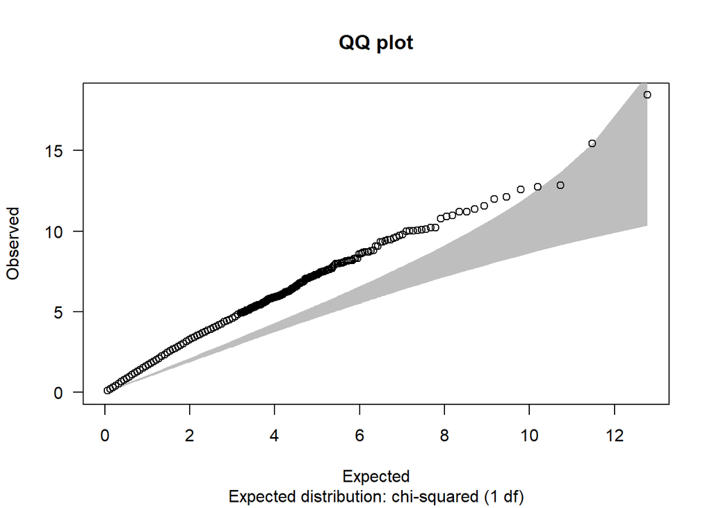

```
##           N     omitted      lambda
## 2851.000000    0.000000    1.657571
```

```r
qq.chisq(chi.squared(glm_all),df=1)
```

## 23. Construct many GLMs, adjusted models with PC’s added

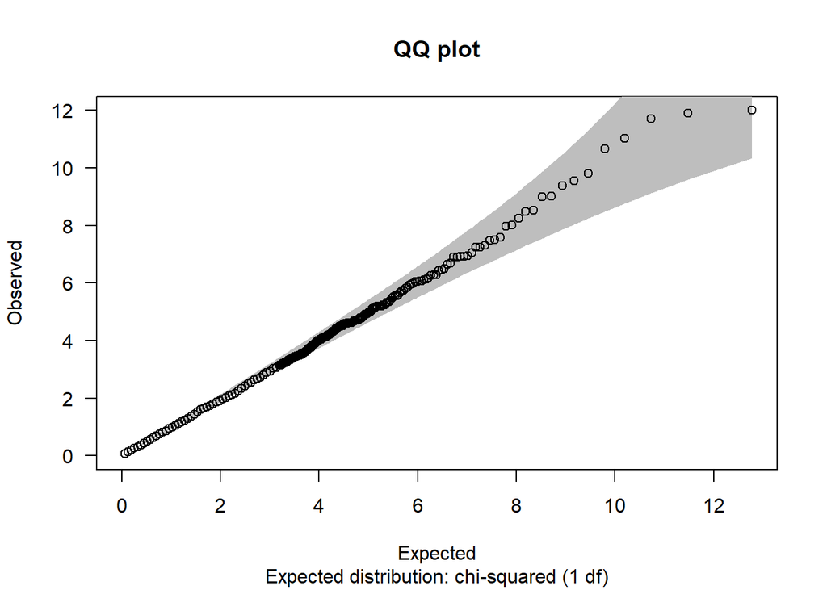

```
##            N      omitted       lambda
## 2851.0000000    0.0000000    0.9770849
```

```r
glm_all_adj = snp.rhs.tests(status ~ pcs,snp.data=sub.10)
qq.chisq(chi.squared(glm_all_adj),df=1)
```

## 24. Load the Bottomly data to construct a Poisson model from count data

```r
con =url("http://bowtie-bio.sourceforge.net/recount/ExpressionSets/bottomly_eset.RData")
load(file=con)
close(con)
bot = bottomly.eset
bot
```

```
## ExpressionSet (storageMode: lockedEnvironment)
## assayData: 36536 features, 21 samples
##   element names: exprs
## protocolData: none
## phenoData
##   sampleNames: SRX033480 SRX033488 ... SRX033494 (21 total)
##   varLabels: sample.id num.tech.reps ... lane.number (5 total)
##   varMetadata: labelDescription
## featureData
##   featureNames: ENSMUSG00000000001 ENSMUSG00000000003 ...
##     ENSMUSG00000090268 (36536 total)
##   fvarLabels: gene
##   fvarMetadata: labelDescription
## experimentData: use 'experimentData(object)'
## Annotation:
```

```r
pdata=pData(bot)
head(pdata)
```

```
##           sample.id num.tech.reps   strain experiment.number lane.number
## SRX033480 SRX033480             1 C57BL/6J                 6           1
## SRX033488 SRX033488             1 C57BL/6J                 7           1
## SRX033481 SRX033481             1 C57BL/6J                 6           2
## SRX033489 SRX033489             1 C57BL/6J                 7           2
## SRX033482 SRX033482             1 C57BL/6J                 6           3
## SRX033490 SRX033490             1 C57BL/6J                 7           3
```

```r
edata=as.matrix(exprs(bot))
head(edata)
```

```
##                    SRX033480 SRX033488 SRX033481 SRX033489 SRX033482 SRX033490
## ENSMUSG00000000001       369       744       287       769       348       803
## ENSMUSG00000000003         0         0         0         0         0         0
## ENSMUSG00000000028         0         1         0         1         1         1
## ENSMUSG00000000031         0         0         0         0         0         0
## ENSMUSG00000000037         0         1         1         5         0         4
## ENSMUSG00000000049         0         1         0         1         0         0
##                    SRX033483 SRX033476 SRX033478 SRX033479 SRX033472 SRX033473
## ENSMUSG00000000001       433       469       585       321       301       461
## ENSMUSG00000000003         0         0         0         0         0         0
## ENSMUSG00000000028         0         7         6         1         1         1
## ENSMUSG00000000031         0         0         0         0         0         0
## ENSMUSG00000000037         0         0         0         0         4         1
## ENSMUSG00000000049         0         0         0         0         0         0
##                    SRX033474 SRX033475 SRX033491 SRX033484 SRX033492 SRX033485
## ENSMUSG00000000001       309       374       781       555       820       294
## ENSMUSG00000000003         0         0         0         0         0         0
## ENSMUSG00000000028         1         1         1         2         1         1
## ENSMUSG00000000031         0         0         0         0         0         0
## ENSMUSG00000000037         1         0         1         2         1         1
## ENSMUSG00000000049         0         0         0         0         0         0
##                    SRX033493 SRX033486 SRX033494
## ENSMUSG00000000001       758       419       857
## ENSMUSG00000000003         0         0         0
## ENSMUSG00000000028         4         1         5
## ENSMUSG00000000031         0         0         0
## ENSMUSG00000000037         1         1         2
## ENSMUSG00000000049         0         0         0
```

```r
fdata = fData(bot)
head(fdata)
```

```
##                                  gene
## ENSMUSG00000000001 ENSMUSG00000000001
## ENSMUSG00000000003 ENSMUSG00000000003
## ENSMUSG00000000028 ENSMUSG00000000028
## ENSMUSG00000000031 ENSMUSG00000000031
## ENSMUSG00000000037 ENSMUSG00000000037
## ENSMUSG00000000049 ENSMUSG00000000049
```

```r
ls()
```

```
##  [1] "bot"             "bottomly.eset"   "con"             "edata"
##  [5] "evv"             "fdata"           "glm_all"         "glm_all_adj"
##  [9] "glm1"            "glm1_dom"        "glm2"            "pcs"
## [13] "pdata"           "snp.support"     "snp1"            "snp1_dom"
## [17] "snpdata"         "snps.10"         "status"          "sub.10"
## [21] "subject.support" "tropical"        "use"             "xxmat"
```

## 25. Filter out the lowly expressed genes

```r
edata = edata[rowMeans(edata) > 10, ]
```

## 26. Fit a GLM, Poisson model on the Bottomly data

```r
glm3 = glm(edata[1, ] ~ pdata$strain,family="poisson")
tidy(glm3)
```

```
## # A tibble: 2 × 5
##   term               estimate std.error statistic p.value
##   <chr>                 <dbl>     <dbl>     <dbl>   <dbl>
## 1 (Intercept)          6.24      0.0140    447.   0
## 2 pdata$strainDBA/2J   0.0498    0.0191      2.61 0.00898
```

## 27. Fit a GLM, Negative Binomial model.

Which offers more flexibility in terms of variance than the Poisson model (where mean & variance are the same)

```r
glm.nb1 = glm.nb(edata[1, ] ~ pdata$strain)
tidy(glm.nb1)
```

```
## # A tibble: 2 × 5
##   term               estimate std.error statistic p.value
##   <chr>                 <dbl>     <dbl>     <dbl>   <dbl>
## 1 (Intercept)          6.24       0.121    51.8     0
## 2 pdata$strainDBA/2J   0.0498     0.167     0.299   0.765
```

## 28. Fit a GLM, Negative Binomial model on many genes using the DESeq package

### 28. A. Build a DESeq data set

```r
de = DESeqDataSetFromMatrix(edata, pdata, ~strain)
```

```
##   Note: levels of factors in the design contain characters other than
##   letters, numbers, '_' and '.'. It is recommended (but not required) to use
##   only letters, numbers, and delimiters '_' or '.', as these are safe characters
##   for column names in R. [This is a message, not a warning or an error]
```

### 28. B. Construct the models

```r
glm_all_nb = DESeq(de)
```

[output not shown]

[output not shown]

[output not shown]

```
## -- replacing outliers and refitting for 2 genes
## -- DESeq argument 'minReplicatesForReplace' = 7
## -- original counts are preserved in counts(dds)
```

[output not shown]

### 28. C. Accessing the results of the Negative Binomial Model on many genes

```r
result_nb = results(glm_all_nb)
```

### 28. D. Histogram of the statistics

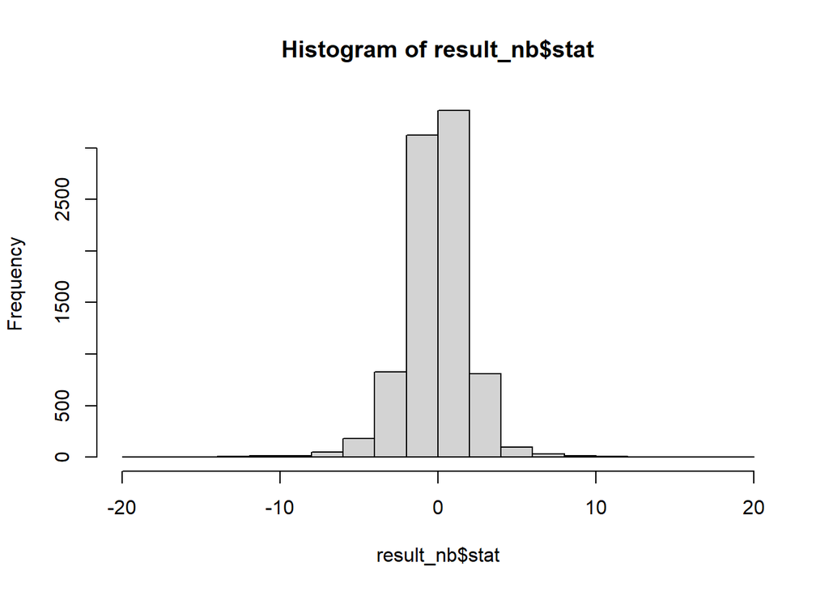

```r
hist(result_nb$stat)
```

```r
Sys.Date()
```

```
## [1] "2025-11-26"
```